# Stats 306, Winter 2024, Homework 1

Jialiang Wu, alfredwu

## Question 1 (3 points, 1 each per subproblem)

In this section, we will use git from the command line to learn more about version control. If you have this document, you have probably already used git to retrieve our class repository. If not, follow the directions in lecture00 to get your own copy of the repository.

When you start RStudio on posit Cloud, typically the *Terminal* pane will default to your repository’s directory which is /cloud/project folder. You verify this using the print working directory command, `pwd`.

### Setting up git

Using the *Terminal* pane, add you user name and email:

```bash
git config --global user.name "alfred"
git config --global user.email "alfredwu@umich.edu"
```

The `config` subcommand also lets you retrieve settings. Run `git config user.name` and `git config user.email` to verify your results.

Put a copy of your session here:

```
$ git config user.name
$ git config user.email
```

### Using the log

Every commit in git gets its own identifier and log message. Using the `git log` command you can see the entire log. Since this is quite long, it will be “paginated”. You can scroll up and down using arrow keys or the space bar to move pages. Hit ‘q’ to quit.

Each commit will look something like this:

```
commit COMMIT_ID
Author: Author Name <author_email@email.com>
Date:   DATE AND TIME +0000

    A short message describing the commit.
```

For the most recent commit, fill out the following information:

- Commit id: 64eb84fb70196fffc36a741707bbe10a64987e92
- Author:Mark Fredrickson mfredric@umich.edu
- Date: Mon Jan 22 20:44:36 2024 +0000
- Message: small edits problem one for the Posit environment

### Commiting to your local repository

By this point you have made some changes to this hw01 file. Save the file.

Go to the *Terminal* and type `git status`. What is this telling your?

```
The terminal says "Changes not staged for commit", and the sentence "modified: hw01.Rmd" is red
```

Use `git add hw01.Rmd` to place your changes in the staging area. Type `git status` again to see what happened.

```
the terminal adds "changes to be committed", and it is green
```

Right now, your homework is only “staged”. Next, commit it with `git commit -m "A COMMIT MESSAGE"`. What was the commit ID of your changes? Verify by running `git log COMMIT_ID`. This should give you the log entry for your commit. Include it below.

```
The commit ID: 82ad7994aaf1d31f53920decb50ee7173dc718d7
```

While working, you can save this file and use `git add` and `git commit` to periodically save your changes. This will allow you return to an earlier version if you wish. For now, the easiest way to see your earlier versions will be to use the *Git* tab in the upper left pane. We’ll cover command line ways to get more detailed history later.

## Question 2 (3 points)

### Keeping code DRY (1 point)

A fundamental principle of good computer programming is avoiding repetition of code. The acronym DRY stands for Don’t Repeat Yourself. Using *variables*, clean up the code below to avoid repetition.

```r
r = 7 / 2
# A circle with diameter 7 has a circumference of
C <- 7 * pi

# A circle with diameter 7 has an area of
S <- r^2 * pi

# A cylinder, with a face diameter of 7 and height of 16, has a volume of
V <- S * 16
```

### Mean and Variance (2 points)

The sample mean is defined as:

$$\bar X_n = \frac{1}{n} \sum_{i = 1}^n
X_i$$

and the sample variance is defined as
$$\hat \sigma^2 = \frac{1}{n - 1} \sum_{i=1}^n (X_i - \bar
X_n)^2$$

Using *vectorized* computations, compute the sample mean and sample variance of the `displ` column of the `mpg` data set. Do not use the functions `mean` or `var`. You may use `length` and `sum`.

## Question 3 (4 points)

```r
mean_displ <- sum(mpg$displ) / length(mpg$displ)
mean_displ == mean(mpg$displ)
```

```
## [1] TRUE
```

```r
square_diff <- (mpg$displ - mean_displ)^2
std_displ <- sum(square_diff) / (length(mpg$displ) - 1)
(std_displ - sd(mpg$displ)^2) < 0.0001
```

```
## [1] TRUE
```

### Starwars Characters (1 points)

Investigate the data set `starwars`. Answer the following

- How many characters are listed?
- What kind of data is the `species` column?
- Explain what the value `NA` means in the `hair_color` column.
- How many characters are from Tatooine?
- For humans, what is the average (mean) age?

```r
dim(starwars)
```

```
## [1] 87 14
```

```r
## "There are 87 characters are listed"

class(starwars$species)
```

```
## [1] "character"
```

```r
## "The 'species' column is character"

## "NA means the hair color of the corresponding character is unknown or the character does not have hair"

sum(starwars$homeworld == "Tatooine", na.rm = TRUE)
```

```
## [1] 10
```

```r
## "There are 10 characters are from Tatooine"

human <- starwars[starwars$species == "Human",]
ave_age <- mean(human$birth_year, na.rm = TRUE)
cat("Humans' average age is", ave_age)
```

```
## Humans' average age is 53.74231
```

### Height and Mass (1 points)

Create a scatter plot of the columns `height` and `mass` from the `starwars` data set. What jumps out from the plot? Do a little investigation to find out about that point.

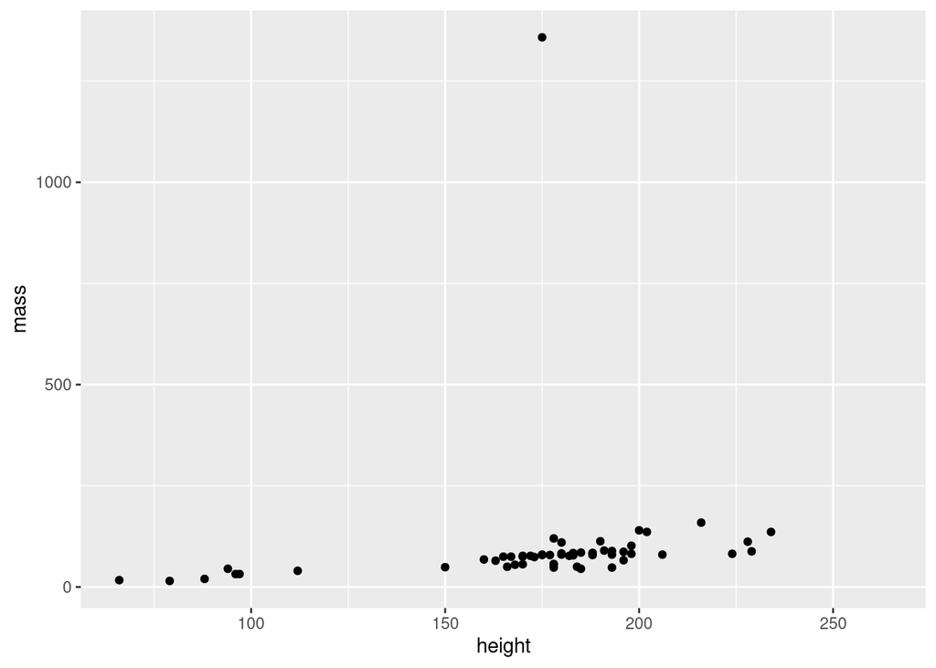

```r
ggplot(data = starwars) + geom_point(aes(x = height, y = mass),na.rm = TRUE)
```

```r
data_correct <- is.na(starwars$mass & starwars$height)
data <- starwars[!data_correct,]
noise <- data[data$mass > 1000,]

print("The exception is a Hutt, maybe is because of his specise")
```

```
## [1] "The exception is a Hutt, maybe is because of his specise"
```

### Challenge problem (2 points)

Each problem set will feature one or two questions that go a bit beyond what we have covered in lab and lecture. The goal of these is for you to learn how to use online resources (R’s help, Google, Stack Overflow, etc.) to solve programming challenges that you have not encountered before. This is an important skill that you will use constantly as a data scientist in the real world.

Load the mpg data set, and use it to reproduce the following horizontal box and whisker plot that shows the distribution of city miles per gallon for each distinct value you see in the class column. Highlight the outliers in red.

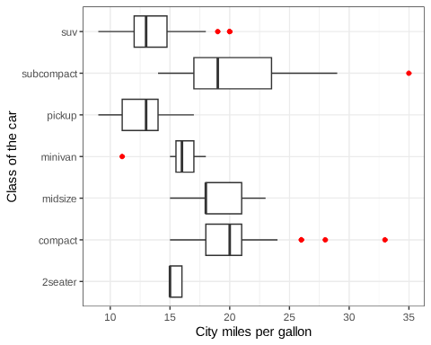

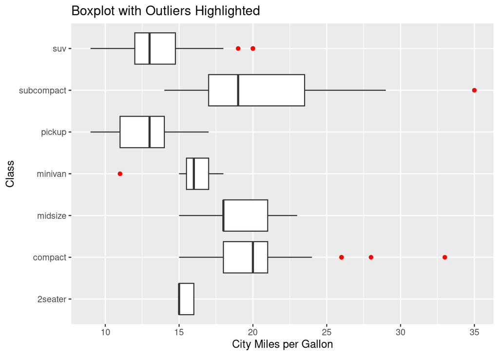

```r
ggplot(data = mpg, aes(x = cty, y = class)) + geom_boxplot(outlier.colour = "red") + labs(title = "Boxplot with Outliers Highlighted", x = "City Miles per Gallon", y = "Class")
```